# Modeling Fantasy Football Statistics

Shane Hylton

2022-12-14

# Introduction

- 3 Key Questions
  - Can I Predict Fantasy Points Given only Targets as Input?
  - Can I Predict Fantasy Points Given Targets and Yards Per Reception?
  - Can I Predict Touchdowns Given All Inputs?

[figure not shown]

ESPN Top 3 Week 13 Wide Receiver Projections

# Data Overview

Summary of Season Data

|  | REC | TGT | YDS | YPR | LG |
| --- | --- | --- | --- | --- | --- |
|  | Min. : 0.000 | Min. : 0.00 | Min. : -5.00 | Min. :-5.000 | Min. : 0.000 |
|  | 1st Qu.: 0.000 | 1st Qu.: 0.00 | 1st Qu.: 0.00 | 1st Qu.: 0.000 | 1st Qu.: 0.000 |
|  | Median : 0.000 | Median : 0.00 | Median : 0.00 | Median : 0.000 | Median : 0.000 |
|  | Mean : 1.078 | Mean : 1.69 | Mean : 13.59 | Mean : 3.866 | Mean : 6.407 |
|  | 3rd Qu.: 1.000 | 3rd Qu.: 2.00 | 3rd Qu.: 12.00 | 3rd Qu.: 7.000 | 3rd Qu.: 9.000 |
|  | Max. :14.000 | Max. :19.00 | Max. :193.00 | Max. :75.000 | Max. :98.000 |

Summary of Season Data Continued

|  | X20. | TD | ATT | RuYD | RuTD |
| --- | --- | --- | --- | --- | --- |
|  | Min. :0.0000 | Min. :0.00000 | Min. :0.00000 | Min. :-26.0000 | Min. :0.000000 |
|  | 1st Qu.:0.0000 | 1st Qu.:0.00000 | 1st Qu.:0.00000 | 1st Qu.: 0.0000 | 1st Qu.:0.000000 |
|  | Median :0.0000 | Median :0.00000 | Median :0.00000 | Median : 0.0000 | Median :0.000000 |
|  | Mean :0.3196 | Mean :0.07543 | Mean :0.07837 | Mean : 0.4502 | Mean :0.004409 |
|  | 3rd Qu.:0.0000 | 3rd Qu.:0.00000 | 3rd Qu.:0.00000 | 3rd Qu.: 0.0000 | 3rd Qu.:0.000000 |
|  | Max. :9.0000 | Max. :3.00000 | Max. :8.00000 | Max. : 68.0000 | Max. :2.000000 |

# Data Overview

Summary of Season Data Continued

|  | FL | G | FPTS | Week |
| --- | --- | --- | --- | --- |
|  | Min. :0.00000 | Min. :0.000 | Min. :-4.000 | Min. : 1.000 |
|  | 1st Qu.:0.00000 | 1st Qu.:0.000 | 1st Qu.: 0.000 | 1st Qu.: 3.000 |
|  | Median :0.00000 | Median :0.000 | Median : 0.000 | Median : 6.000 |
|  | Mean :0.01445 | Mean :0.399 | Mean : 2.939 | Mean : 6.494 |
|  | 3rd Qu.:0.00000 | 3rd Qu.:1.000 | 3rd Qu.: 2.600 | 3rd Qu.: 9.000 |
|  | Max. :2.00000 | Max. :1.000 | Max. :44.800 | Max. :12.000 |

# Data Overview

### Correlation:

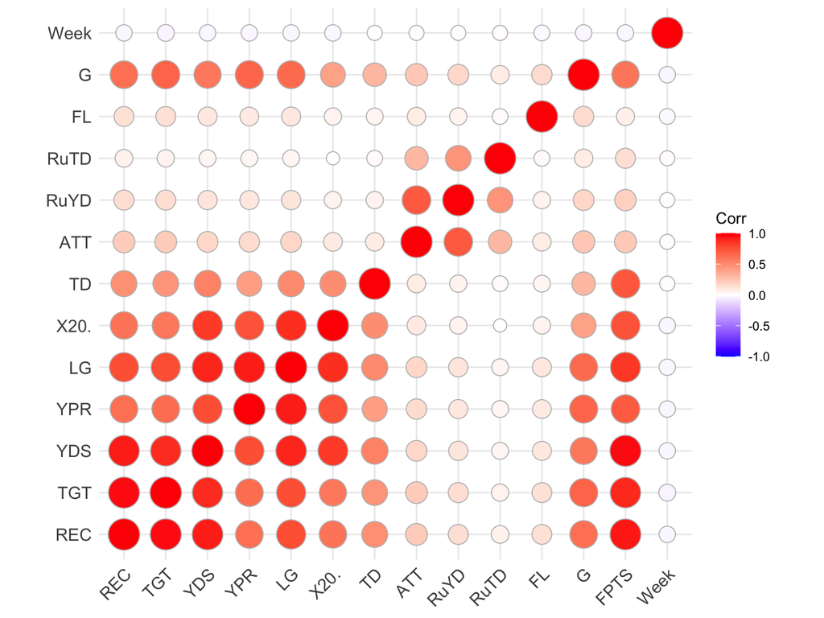

# Data Overview

### Relationship to Fantasy Point Total

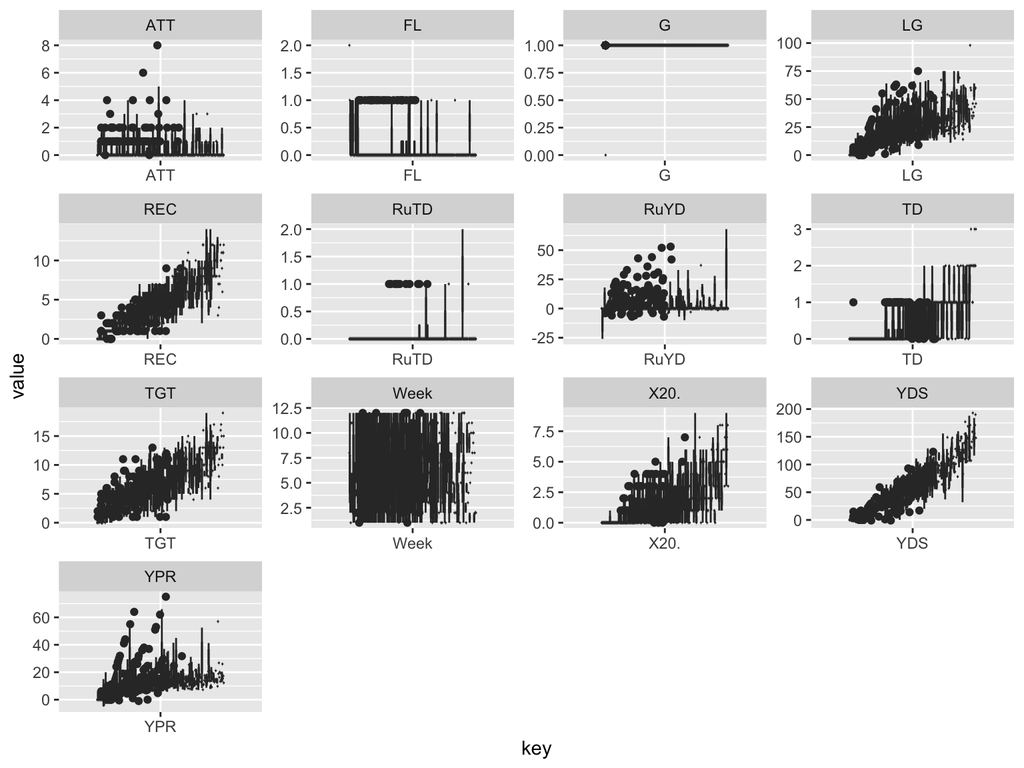

# Question 1: Fantasy Points Given Targets

- Model 1: Simple Linear Regression
  - FPTS ~ TGT Linear Model

```
## [1] "R-Squared:  0.792"
```

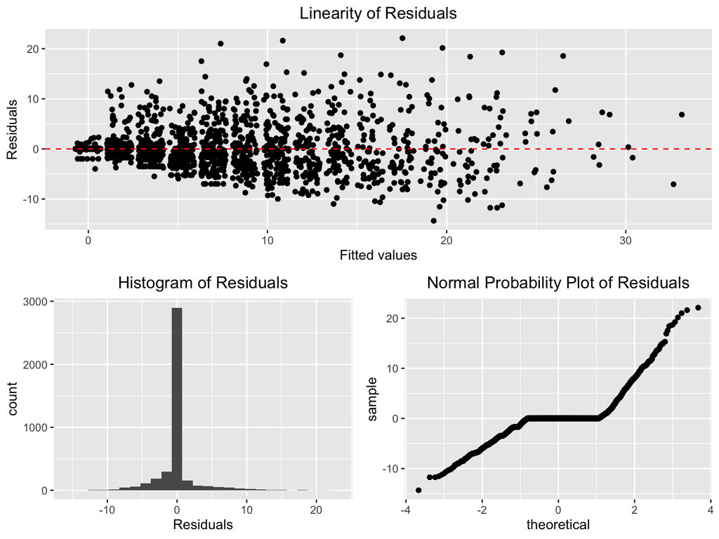

# Question 1: Fantasy Points Given Targets

- Model 2: XGBoost Linear Regression
  - FPTS ~ TGT Linear Model

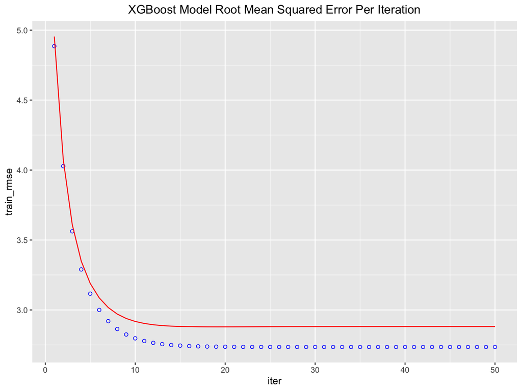

# Question 1: Fantasy Points Given Targets

- Model 2: XGBoost Linear Regression

XGBoost Model Metrics

|  | XGBoost Model Score |
| --- | --- |
| Mean_Squared_Error | 8.300 |
| Root_Mean_Squared_Error | 2.881 |
| Test_Mean | 3.141 |
| R_Squared | 0.728 |

```
##                         XGBoost Model Score
## Mean_Squared_Error                    8.300
## Root_Mean_Squared_Error               2.881
## Test_Mean                             3.141
## R_Squared                             0.728
```

### Comments

The XGBoost Model is prone to overfitting. The parameter, eta, is the main valve to open or close to limit overfitting. A lower eta value will help prevent overfitting.

# Question 2: Fantasy Points Given Targets and Yards Per Catch

- Model 3: Multiple Regression

```
## [1] "R-Squared:  0.827"
```

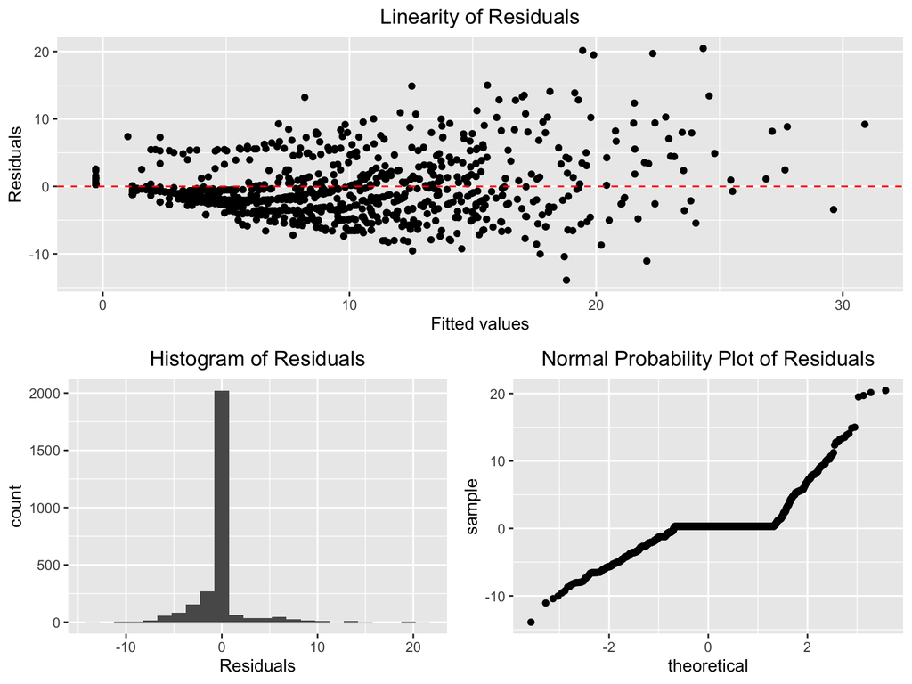

# Question 2: Fantasy Points Given Targets and Yards Per Catch

- Model 4: Negative Binomial

The Negative Binomial Model provides a very poor fit. With an AIC of 6795.4 and predictions that are immensely far from expectation, this model will not be included.

# Question 2: Fantasy Points Given Targets and Yards Per Catch

- Model 5: XGBoost Regression Model with TGT and YPR as Inputs

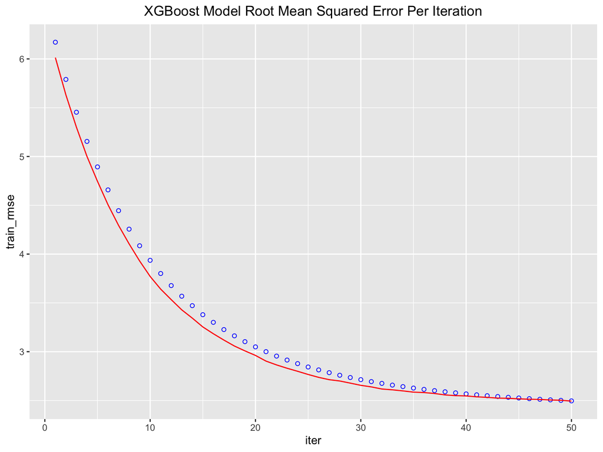

# Question 2: Fantasy Points Given Targets and Yards Per Catch

- Model 5: XGBoost Regression Model with TGT and YPR as Inputs
  - Importance Plot

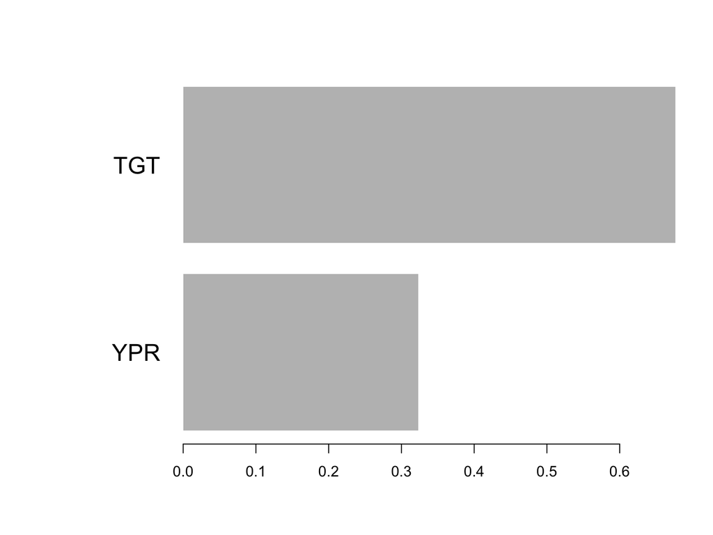

# Question 2: Fantasy Points Given Targets and Yards Per Catch

- Model 5: XGBoost Regression Model with TGT and YPR as Inputs
  - Model Metrics

XGBoost Model Metrics

|  | XGBoost Model Score |
| --- | --- |
| Mean_Squared_Error | 6.217 |
| Root_Mean_Squared_Error | 2.493 |
| Test_Mean | 2.887 |
| R_Squared | 0.755 |

```
##                         XGBoost Model Score
## Mean_Squared_Error                    6.217
## Root_Mean_Squared_Error               2.493
## Test_Mean                             2.887
## R_Squared                             0.755
```

# Question 3: Touchdowns Given All Inputs

- Fantasy point totals will not be included in the touchdown prediction
  - Model 6: Multiple Regression
    - As expected, the model falls well short of correctly projecting touchdowns.

```
## [1] "R-Squared:  0.302"
```

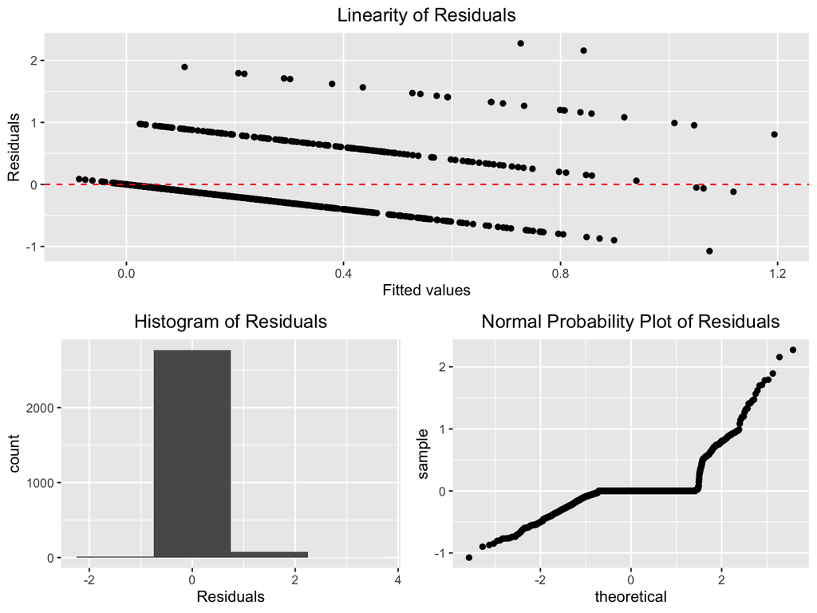

# Question 3: Touchdowns Given All Inputs

- Model 7: XGBoost Touchdowns From All Inputs

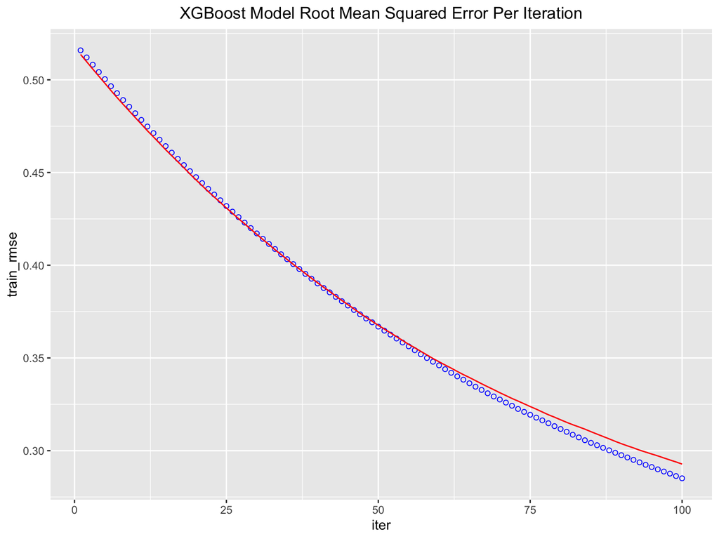

# Question 3: Touchdowns Given All Inputs

- Model 7: XGBoost Touchdowns From All Inputs
- Importance Plot

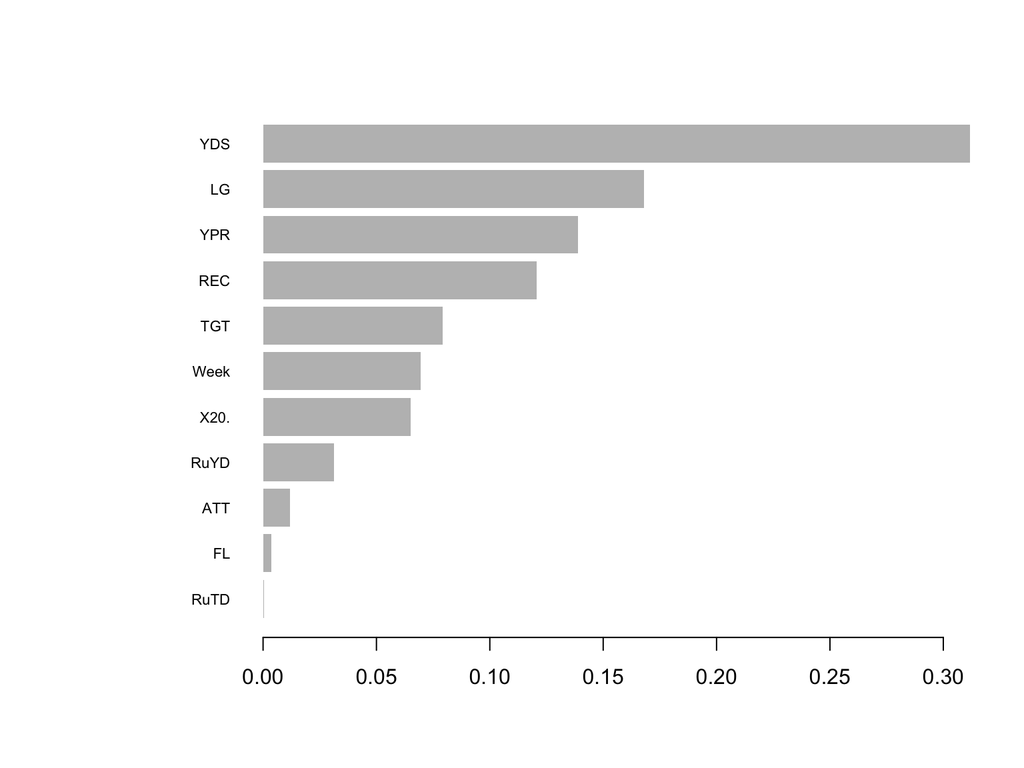

# Question 3: Touchdowns Given All Inputs

- Model 7: XGBoost Touchdowns From All Inputs
- Model Metrics

XGBoost Model Metrics

|  | XGBoost Model Score |
| --- | --- |
| Mean_Squared_Error | 0.086 |
| Root_Mean_Squared_Error | 0.293 |
| Test_Mean | 0.233 |
| R_Squared | -7.179 |

```
##                         XGBoost Model Score
## Mean_Squared_Error                    0.086
## Root_Mean_Squared_Error               0.293
## Test_Mean                             0.233
## R_Squared                            -7.179
```

### Comments

Touchdowns are effectively random. In the knitted document, the seed is different from what it was when the model originally ran, and the $R^2$ decreased from 0.95 to a negative value.

# Model Selection and Week 14 Predictions

### Week 14 Projections

[figure not shown]

# Week 14 Performance

Week 14 Fantasy Point Prediction Results

|  | XGB Multiple: | Multiple: | Linear: | XGBoost Linear: |
| --- | --- | --- | --- | --- |
| RMSE | 2.346 | 2.363 | 2.524 | 2.523 |

### Comments

Overall, in Week 14, the models that performed the best were the XGBoost multiple regression and the standard multiple regression model that took into account expected yards per reception and targets.

# Sources:

“Fantasy Football Scoring Leaders.” ESPN, ESPN Internet Ventures, https://fantasy.espn.com/football/leaders?lineupSlot=4&scoringPeriodId=13&statSplit=singleScoringPeriod.

“Week 14 NFL WR Statistics.” FantasyPros, https://www.fantasypros.com/nfl/stats/wr.php?range=week&week=14.